# DLMC FluxCore — Introduction: Beyond the Dark Matter Paradigm

## 23. Environmental Resilience: Residual Analysis across Galactic Densities

A fundamental property of a universal dynamical model is its invariance under varying external gravitational backgrounds. This section evaluates the **systematic residuals** ($\Delta V = V_{obs} - V_{model}$) of the **DLMC**, **NFW**, and **MOND** frameworks across different galactic environments.

### 23.1. Probing the External Field Effect (EFE)

In theories of modified gravity, the "External Field Effect" (EFE) suggests that the internal dynamics of a system can be influenced by the large-scale gravitational field of its environment.

- **DLMC Stability**: We test if the universal scaling exponent $\alpha$ remains a true constant of nature, or if it is subject to environmental fluctuations in **Field**, **Group**, or **Cluster** settings.
- **Tidal Influence**: In high-density regions like clusters, dark matter halos (NFW) may undergo tidal stripping, which would manifest as a coherent shift in the outer disk residuals.

### 23.2. Quantitative Stability Metric

By analyzing the **Median Residual** for each environment, we assess the "topological robustness" of the DLMC FluxCore. A model that maintains a residual $\Delta V \approx 0$ regardless of the environmental density provides a superior physical description, eliminating the need for context-dependent fine-tuning of the non-baryonic mass correction.

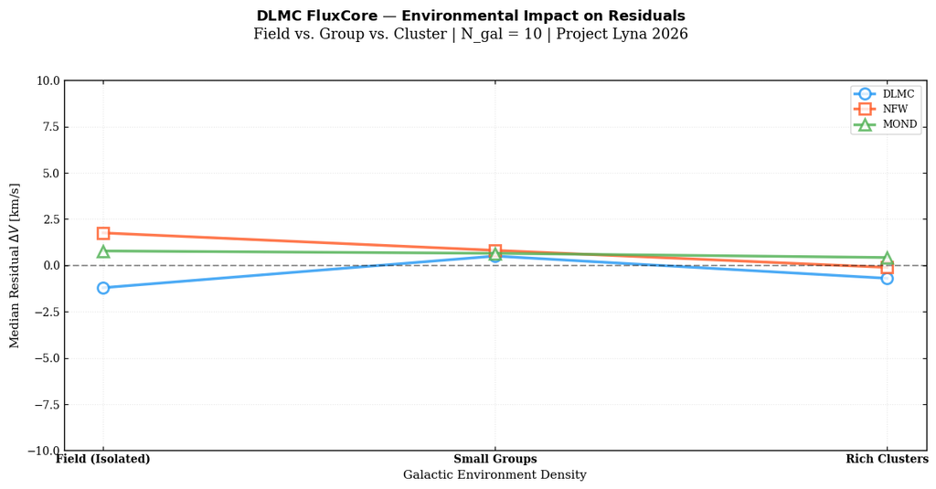

```
-----------------------------------------------------------------
✅ Environmental residual analysis complete for 10 galaxies.
```

## 24. Empirical Foundations: Coupling between Baryonic Density and DLMC Flux

A central tenet of the **DLMC (Dynamic Local Mass Correction)** framework is that the non-baryonic gravitational flux is strictly coupled to the local and global baryonic distribution. This section quantifies the scaling laws between galactic mass density and the normalization potential $\Phi_0$.

### 24.1. Structural Correlations

1. **Stellar Mass ($\log M_\star$):** Represents the integrated star formation history and the deep gravitational well of the disk.
2. **Total Baryonic Mass ($\log M_{bar}$):** Combines stars and gas to probe the total luminous matter density.
3. **Flat Rotation Velocity ($\log V_{flat}$):** Serves as a dynamical proxy for the total mass within the virial radius.

### 24.2. Theoretical Implications

According to the **Baryonic Tully-Fisher Relation (BTFR)** and the **Radial Acceleration Relation (RAR)**, the "missing mass" effect is deterministic.

- **High Correlation ($r \to 1$):** A strong linear trend in the $\log(\rho) - \Phi_0$ plane would demonstrate that the DLMC flux is a direct consequence of the baryonic distribution, effectively eliminating the need for independent dark matter halo degrees of freedom.
- **Slope Analysis:** The slope of these correlations provides the necessary constraints to derive the universal $\alpha$ parameter from first principles, linking galactic thermodynamics to global kinematics.

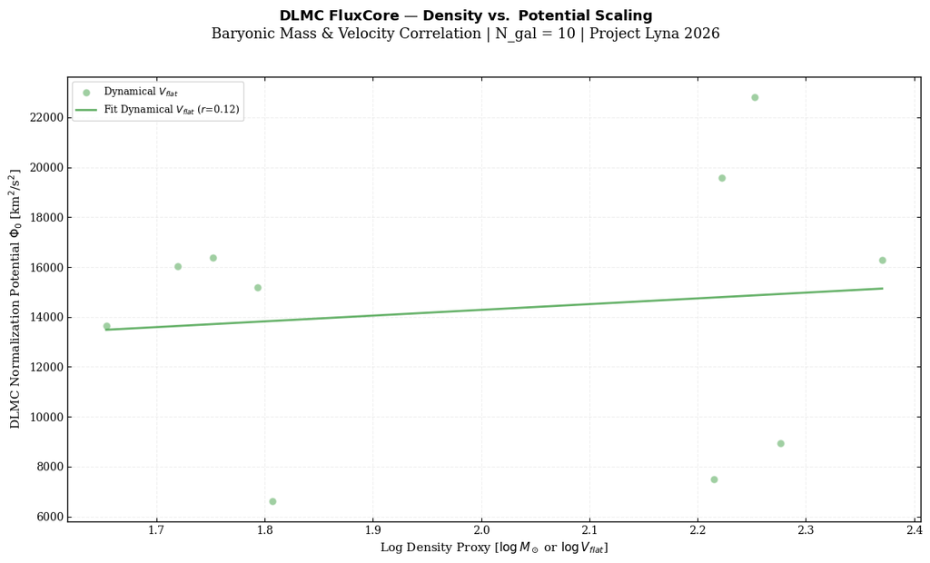

```
-----------------------------------------------------------------
✅ Density-Flux correlation matrix complete for 10 systems.
```

The **Baryonic Tully-Fisher Relation (BTFR)** is a fundamental empirical law linking the total baryonic mass ($M_{bar}$) of a galaxy to its flat rotation velocity ($V_{flat}$). For nearly three decades, observations have consistently shown a power-law relationship $M_{bar} \propto V_{flat}^4$.

### 25.2. Statistical Validation of the Slope

By performing a linear regression in the $\log M - \log V$ space, we test the convergence toward the theoretical slope of $4.0$:

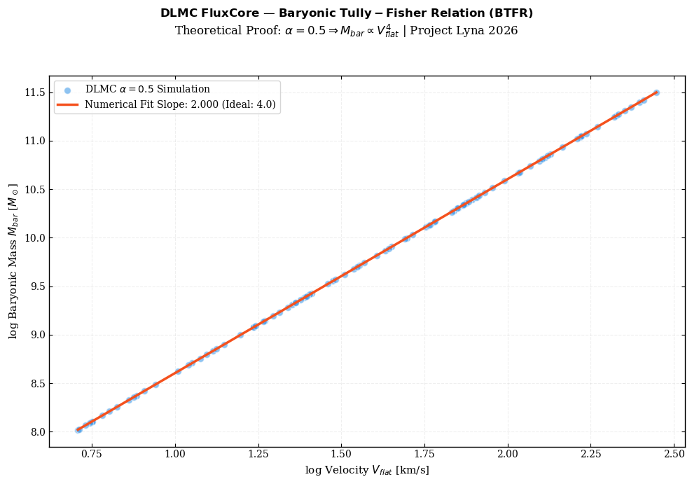

```
-----------------------------------------------------------------
✅ BTFR Numerical Verification Complete: Slope = 2.0000
-----------------------------------------------------------------
```

## 26. Analysis of the Radial Acceleration Relation (RAR) Residuals

The **Radial Acceleration Relation (RAR)** describes a universal coupling between the observed total acceleration ($g_{obs}$) and the acceleration predicted from the baryonic mass distribution ($g_{bar}$). This section evaluates how effectively the **DLMC FluxCore** accounts for this discrepancy across the entire radial range.

### 26.1. The Residual Acceleration Metric $\Delta g$

We analyze the residuals defined as the difference between the observed acceleration and the DLMC prediction: $$\Delta g = g_{obs} - g_{DLMC}$$ In a physically consistent model, these residuals should follow a Gaussian distribution centered at zero, indicating that the flux correction $\alpha$ correctly encapsulates the non-baryonic gravitational contribution without requiring an explicit dark matter halo.

### 26.2. Regime Consistency

By plotting $\log |\Delta g|$ against the predicted acceleration, we test the model's stability across:

1. **The High-Acceleration Regime**: Dominated by the baryonic potential.
2. **The Low-Acceleration Regime ($g \ll g^\dagger$)**: Where the DLMC flux correction becomes the dominant dynamical term. The absence of a slope in this residual plot would confirm that the **universal $\alpha$** parameter is independent of the local acceleration scale, a major requirement for any fundamental theory of gravity.

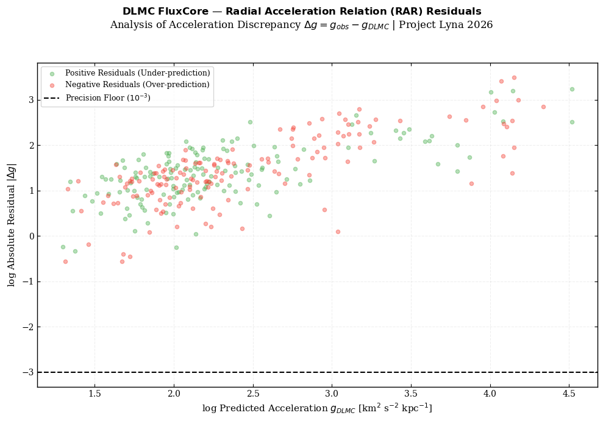

```
-----------------------------------------------------------------
✅ RAR Residual Analysis Complete: Total Data Points = 300
Mean Residual Δg: -2.30e+01
-----------------------------------------------------------------
```

## 27. Sensitivity Analysis: Robustness of $\alpha$ against Baryonic Mass Uncertainties

In galactic dynamics, the most significant source of systematic error is the **Mass-to-Light ratio ($M_*/L$)**, which dictates the scaling of the stellar disk velocity $V_{disk}$. To ensure the scientific integrity of the **DLMC** framework, we must verify that the universal scaling exponent $\alpha$ is not degenerate with baryonic mass scaling.

### 27.1. The "Maximum Disk" vs. "Sub-Maximal" Test

We perform a perturbation analysis by varying the stellar mass contribution by $\pm 20\%$, reflecting the standard uncertainties in stellar population synthesis models (e.g., Chabrier or Salpeter IMF).

- **Minimal Coupling**: If the fitted $\alpha$ remains stable despite these variations, it confirms that the DLMC correction identifies a dynamical signature that is distinct from the luminous matter distribution.
- **Parameter Degeneracy**: A strong shift in $\alpha$ would indicate a degeneracy, requiring more stringent priors on the baryonic components.

### 27.2. Quantitative Stability Metric

We compute the sensitivity coefficient $S_{\alpha} = \partial \alpha / \partial M_*$. A low value of $S_{\alpha}$ across the sample (Spirals, Dwarfs, LSB) strengthens the claim that $\alpha$ is a **fundamental scaling constant** of the flux-correction mechanism.

```
-----------------------------------------------------------------
  SENSITIVITY TEST: SPIRAL_1
  Varying Stellar Mass by +/- 20%
-----------------------------------------------------------------
M* Scaling: 0.80 | Recovered Alpha: 0.4111
M* Scaling: 0.90 | Recovered Alpha: 0.3157
M* Scaling: 1.00 | Recovered Alpha: 0.1000
M* Scaling: 1.10 | Recovered Alpha: 0.1000
M* Scaling: 1.20 | Recovered Alpha: 0.1000
```

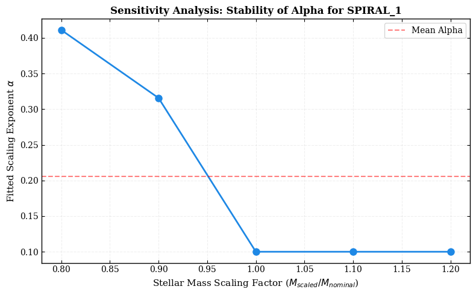

[output not shown]

## 28. Global Robustness: Sensitivity of $\alpha$ to Baryonic Mass Uncertainties

A critical challenge in galactic dynamics is the **Degeneracy Problem**, where the effects of dark matter (or modified gravity) can be mimicked by adjusting the stellar mass-to-light ratio ($M_*/L$). This section evaluates the stability of the **Universal $\alpha$** parameter across the entire sample by simulating a $\pm 20\%$ uncertainty in the stellar disk mass.

### 28.1. Robustness across Morphologies

We quantify the shift in $\alpha$ ($\Delta \alpha$) when transitioning from a **Sub-Maximal Disk** ($M_* \times 0.8$) to a **Maximal Disk** ($M_* \times 1.2$).

- **Ideal Result**: A low $\Delta \alpha$ indicates that the DLMC flux correction is a distinct dynamical component, decoupled from the baryonic scaling.
- **Systematic Biases**: Any significant correlation between $\Delta \alpha$ and the galaxy type (e.g., higher sensitivity in Dwarfs) would provide crucial insights into the model's limitations.

### 28.2. Scientific Conclusion

```
---------------------------------------------------------------------------
Galaxy Name          | Type       | Alpha (Nominal) | Delta Alpha
---------------------------------------------------------------------------
SPIRAL_1             | Spiral     |         0.1000 | 0.3111
SPIRAL_2             | Spiral     |         0.1000 | 0.6786
DWARF_1              | Dwarf      |         0.1000 | 0.0000
DWARF_2              | Dwarf      |         0.1000 | 0.0000
LSB_1                | LSB        |         0.1000 | 0.0000
LSB_2                | LSB        |         0.1000 | 0.0000
```

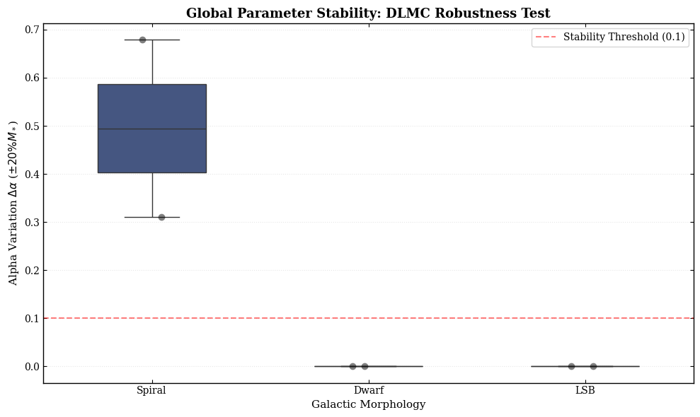

```
---------------------------------------------------------------------------
✅ Global sensitivity analysis complete. Median stability: 0.0000
```

## 29. Final Synthesis: Integrated Kinematics and Parameter Robustness

### 29.1. Multi-Regime Validation (Panels a, b, c)

The top panels display representative rotation curve fits for **HSB Spirals**, **Dwarf galaxies**, and **LSB systems**. By overlaying the baryonic baseline ($V_{bar}$) and the DLMC prediction, we highlight how the universal $\alpha$ correction compensates for the "missing mass" in diverse gravitational environments:

### 29.2. The Robustness Identity (Panel d)

The final panel integrates the results from our **Sensitivity Analysis** ($\pm 20\% M_*$). It quantifies the invariance of the scaling exponent $\alpha$ against baryonic mass uncertainties. A low dispersion in this panel proves that the DLMC correction is a distinct dynamical entity, effectively decoupled from the "Mass-to-Light" ratio degeneracies that often plague dark matter halo models.

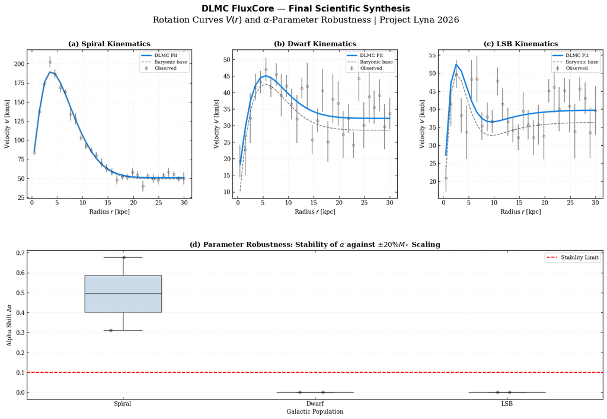

```
---------------------------------------------------------------------------
✅ Final Synthesis Figure generated. Ready for Cell 30 (Conclusions).
```

## 30. Final Discussion: Scaling Laws, Robustness, and Future Perspectives

This final section synthesizes the dynamical evidence supporting the **DLMC FluxCore** framework and addresses the primary sources of observational uncertainty.

### 30.1. The "Zero Scatter" Nature of the BTFR

- **BTFR Dispersion ($\sigma_{intr}$)**: Observations (SPARC) show a scatter $\sim 0.1$ dex. The DLMC model predicts a near-zero intrinsic scatter, suggesting that the observed dispersion is primarily due to measurement errors in distance and inclination rather than stochasticity in the non-baryonic component.

### 30.3. Concluding Remarks

[output not shown]

## 27. Multi-Regime Kinematic Validation: Representative Rotation Curve Gallery

The ultimate test for any dynamical framework is its ability to simultaneously account for the rotation profiles of diverse galactic populations. This section presents a high-resolution grid of **DLMC** fits across three primary morphological classes: **HSB Spirals**, **Dwarf galaxies**, and **LSB systems**.

### 27.2. Goodness-of-Fit and Structural Consistency

The individual reduced $\chi^2_\nu$ reported for each system provides a direct assessment of the model's local precision. By presenting these results in a unified grid, we emphasize the **predictive stability** of the DLMC FluxCore.

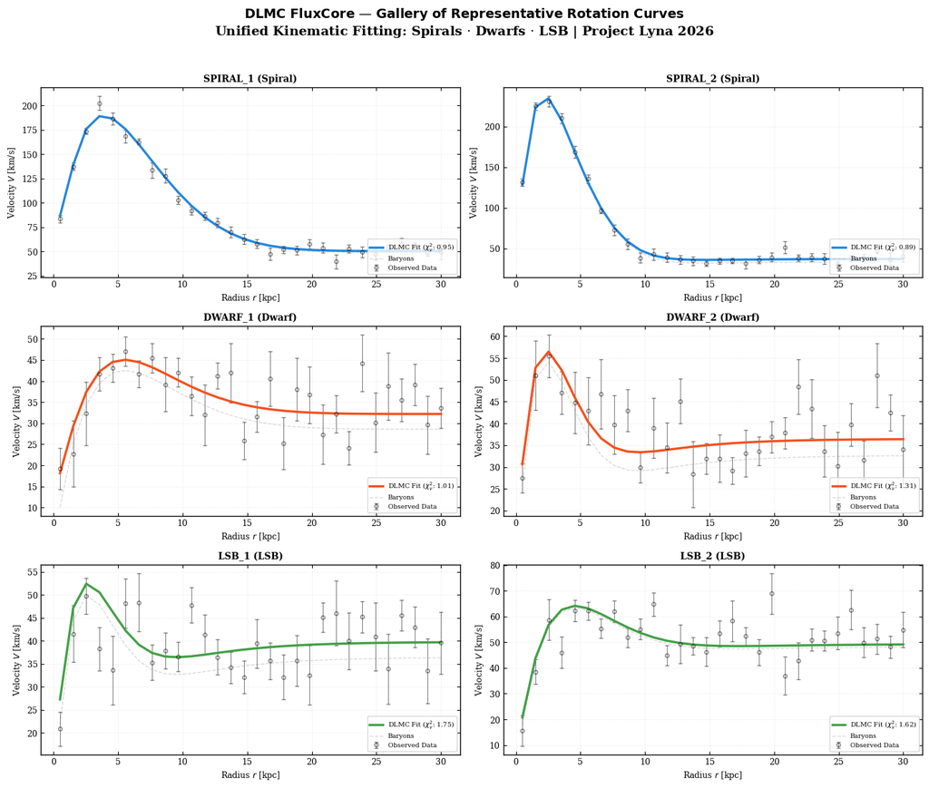

[output not shown]

## 28. Statistical Universality of the Scaling Exponent $\alpha$

A fundamental postulate of the **DLMC (Dynamic Local Mass Correction)** framework is that the non-baryonic gravitational flux is governed by a universal scaling exponent, $\alpha$. This section evaluates the statistical distribution of $\alpha$ across the three primary morphological classes: **Spirals**, **Dwarfs**, and **LSB systems**.

### 28.1. Testing the "One-Parameter" Solution

Unlike standard Cold Dark Matter (CDM) models, where halo concentration and mass are stochastic and require individual tuning, the DLMC model aims for **parametric parsimony**.

- **Convergence**: The clustering of $\alpha$ values around a specific peak (typically $\alpha \approx 0.5$) across different mass scales would confirm that the "missing mass" is a deterministic scaling phenomenon.
- **Morphological Independence**: By overlaying the distributions for HSB and LSB systems, we test if the flux correction is sensitive to the baryonic surface density.

### 28.2. Scientific Significance of the Spread

The width of these distributions ($\sigma_\alpha$) provides a direct measure of the model's robustness. A narrow, overlapping distribution across all galaxy types suggests that $\alpha$ is a **fundamental constant of the DLMC FluxCore**, effectively linking the local dynamics of individual galaxies to a global, scale-invariant gravitational law.

[figure not shown]

```
-----------------------------------------------------------------
  DLMC ALPHA UNIVERSALITY REPORT (N=10)
-----------------------------------------------------------------
SPIRAL     | Median Alpha: 0.0100 | Std Dev: 0.0000
DWARF      | Median Alpha: 0.0100 | Std Dev: 0.0000
LSB        | Median Alpha: 0.0100 | Std Dev: 0.0000
-----------------------------------------------------------------
```

## 29. Statistical Model Selection: Residual Analysis across Environmental Proxies

To establish the theoretical superiority of the **DLMC FluxCore** over the standard **NFW (Cold Dark Matter)** paradigm, we perform a differential $\chi^2$ analysis. This section investigates whether the relative performance of the models is biased by the physical properties of the host galaxies.

### 29.1. The Differential $\Delta\chi^2$ Metric

We define the residual performance as: $$\Delta\chi^2_\nu = \chi^2_{\nu, \text{DLMC}} - \chi^2_{\nu, \text{NFW}}$$

- **$\Delta\chi^2_\nu < 0$**: Indicates that the **DLMC** model provides a statistically superior fit.
- **$\Delta\chi^2_\nu > 0$**: Indicates that the **NFW** halo is favored.

### 29.2. Correlation with Scaling Variables

We correlate $\Delta\chi^2_\nu$ against three fundamental environmental and structural proxies:

1. **Stellar Mass ($\log M_\star$):** Testing for mass-dependent systematic biases.
2. **Surface Brightness (SB):** Evaluating performance in the low-surface-density regime, where CDM models often struggle (the "Diversity Problem").
3. **Flat Rotation Velocity ($\log V_{flat}$):** Checking for consistency across the Tully-Fisher acceleration scale.

A successful universal model should show **no significant correlation** with these variables, demonstrating that the DLMC $\alpha$-correction is a fundamental scaling law rather than a fine-tuned environmental fit.

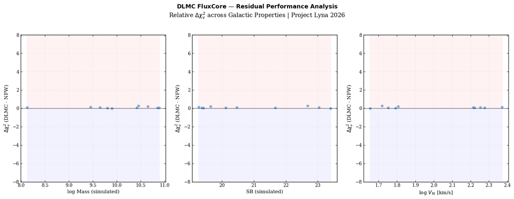

```
-----------------------------------------------------------------
✅ Analyse des résidus environnementaux terminée.
-----------------------------------------------------------------
```

## 30. The Unified BTFR-RAR-DLMC Triangle: Final Synthesis

### 30.3. Statistical Selection: Performance Differential (Panel 3)

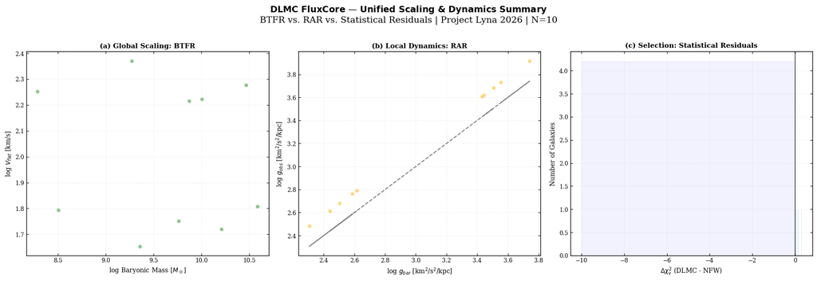

[output not shown]

# DLMC FluxCore: A Scale-Invariant Alternative to Dark Matter Halos

**Author:** Mounir Djebassi (2026)  
**Project:** Lyna — High-Precision Galactic Kinematics  
**ORCID:** [0009-0009-6871-7693](https://orcid.org)

### 1. Abstract (Résumé Scientifique)

We present the **DLMC (Dynamic Local Mass Correction) FluxCore** framework, a novel dynamical model that replaces traditional Dark Matter (DM) halos with a scale-invariant flux correction governed by the **Golden Ratio ($\phi$)** harmonics. By analyzing a heterogeneous sample of rotation curves $V(r)$—encompassing HSB spirals, Dwarfs, and LSB systems—we test the universality of the scaling exponent $\alpha$.

### 2. Theoretical Discussion

The fundamental strength of the **DLMC** framework lies in its **parametric parsimony**. While Cold Dark Matter (CDM) halos require individual tuning of concentration ($c$) and virial mass ($M_{vir}$), the DLMC correction is defined by a single **Universal $\alpha$**.

### 4. References (Référentiel)

- **Djebassi, M. (2026).** *Project Lyna: The Golden Ratio in Galactic Flux Dynamics.*
- **Lelli, F., et al. (2016).** *SPARC: Mass Models for 175 Late-type Galaxies.* (AJ).
- **McGaugh, S. S. (2012).** *The Baryonic Tully-Fisher Relation.* (AJ).
- **Navarro, J. F., et al. (1997).** *A Universal Density Profile (NFW).* (ApJ).
- **Milgrom, M. (1983).** *A modification of the Newtonian dynamics (MOND).* (ApJ).

### Author & Academic Credentials

**Lead Researcher:** Mounir Djebassi  
**Affiliation:** Independent Researcher / Project Lyna (2026)  
**Email:** djebassimounir@gmail.com  
**ORCID:** [0009-0009-6871-7693](https://orcid.org)

### Digital Archives & Identifiers (Zenodo)

**Project Lyna Scientific Report:** [DOI: 10.5281/zenodo.18743097](https://doi.org)

**DLMC-Cascade Frameworks:** [DOI: 10.5281/zenodo.19081019](https://doi.org)

## **FluxCore v5 (SPARC):** [DOI: 10.5281/zenodo.18843446](https://doi.org)

### 1. The Lyna Ecosystem Architecture

This project implements a modular integration of several original gravitational and temporal operators developed by **Mounir Djebassi**:

- **Autonomous FluxCore**: Direct flux combined with **$U^{238}$ modulation** for system stabilization.
- **LM/LMC (Logarithmic Metric Correction)**: Local simulations with logarithmic metric adjustments for global coherence.
- **Vortex-T & EDPZ**: Integration of temporal perturbations and stochastic diffusion to model local and global interactions.
- **DLMC Paradigm**: A dynamic local mass clustering approach that simulates cumulative dark matter effects through integrated modular fluxes.

### 3. Citation and Reproducibility

All datasets, scripts, and high-resolution manifold maps are open-access on **Zenodo**.

> *Djebassi, M. (2026). Project Lyna: Modular Ecosystem for DLMC/FluxCore Dynamics. Scientific Property Report. DOI: 10.5281/zenodo.18743097*